# Les Jeux paralympiques

```r
all_medal_sex <- SW%>% group_by(abb, medal, gender) %>%
  summarise(total = n())
head(all_medal_sex)
```

```
## # A tibble: 6 x 4
## # Groups:   abb, medal [4]
##   abb   medal  gender total
##   <chr> <chr>  <chr>  <int>
## 1 ARG   Bronze Men        2
## 2 ARG   Bronze Women      7
## 3 ARG   Gold   Women      5
## 4 ARG   Silver Men        3
## 5 ARG   Silver Women      7
## 6 AUS   Bronze Men       63
```

```r
all_medal_sex.wide <- dcast(all_medal_sex, abb ~ medal+gender)
all_medal_sex.wide[is.na(all_medal_sex.wide)] <- 0
head(all_medal_sex.wide)
```

```
##   abb Bronze_Men Bronze_Mixed Bronze_Women Gold_Men Gold_Mixed Gold_Women
## 1 ARG          2            0            7        0          0          5
## 2 AUS         63            0           97       72          0         75
## 3 AUT          2            0            0        2          0          0
## 4 AZE          0            0            0        0          0          1
## 5 BAH          0            0            1        0          0          0
## 6 BEL          7            0            6        4          0          2
##   Silver_Men Silver_Mixed Silver_Women
## 1          3            0            7
## 2         78            0           80
## 3          4            0            0
## 4          3            0            4
## 5          0            0            0
## 6          7            0            5
```

#### **8a.Quel sont les pays où juste c’est les hommes qu’y ont gagné la médaille d’or?

```r
no_women_gold <- subset(all_medal_sex.wide, Gold_Women ==0 & Gold_Men>0 )
no_women_gold
```

```
##    abb Bronze_Men Bronze_Mixed Bronze_Women Gold_Men Gold_Mixed Gold_Women
## 3  AUT          2            0            0        2          0          0
## 7  BLR          9            0            0       21          0          0
## 12 COL          4            0            0        2          0          0
## 14 CUB          2            0            0        1          0          0
## 18 EGY          6            0            0        1          0          0
## 21 EUN          4            0            2        4          0          0
## 28 GRE         10            0            1       10          0          0
## 29 HKG          2            0            1        1          0          0
## 31 IPP          0            0            0        1          0          0
## 39 KOR          6            0            0        7          0          0
## 42 LUX          0            0            0        1          0          0
## 48 PER          2            0            0        2          0          0
## 56 SVK          2            0            1        2          0          0
## 59 THA          4            0            0        1          0          0
```

[output cut: 17 more lines]

```r
print(" Les pays où les femmes n'ont jamis remporté de médaille d'or mais où les hommes l'ont remporté")
```

```
## [1] " Les pays où les femmes n'ont jamis remporté de médaille d'or mais où les hommes l'ont remporté"
```

```r
no_women_gold$abb
```

```
##  [1] "AUT" "BLR" "COL" "CUB" "EGY" "EUN" "GRE" "HKG" "IPP" "KOR" "LUX" "PER"
## [13] "SVK" "THA" "YUG"
```

#### **8b.Quel sont les pays où les femmes qu’y ont gagné la médaille d’or ?

```r
no_men_gold <- subset(all_medal_sex.wide, Gold_Women>0 & Gold_Men==0 )
no_men_gold
```

```
##    abb Bronze_Men Bronze_Mixed Bronze_Women Gold_Men Gold_Mixed Gold_Women
## 1  ARG          2            0            7        0          0          5
## 4  AZE          0            0            0        0          0          1
## 15 CYP          0            0            1        0          0          2
## 20 EST          1            0            2        0          0          2
## 25 FRO          0            0            5        0          0          1
## 36 JAM          0            0            0        0          0          1
## 38 KAZ          0            0            0        0          0          1
## 53 SGP          0            0            1        0          0          3
##    Silver_Men Silver_Mixed Silver_Women
## 1           3            0            7
## 4           3            0            4
## 15          0            0            1
## 20          0            0            5
## 25          0            0            7
## 36          0            0            3
## 38          0            0            0
## 53          0            0            1
```

```r
print("Les pays où les hommes n'ont jamis remporté de médaille d'or mais où les femmes l'ont remporté")
```

```
## [1] "Les pays où les hommes n'ont jamis remporté de médaille d'or mais où les femmes l'ont remporté"
```

```r
no_men_gold$abb
```

```
## [1] "ARG" "AZE" "CYP" "EST" "FRO" "JAM" "KAZ" "SGP"
```

```r
noc <- readr::read_csv('https://raw.githubusercontent.com/youmrg/data_R/main/noc_regions.csv')

noc = noc %>%
  rename(abb = NOC)
noc
```

```
## # A tibble: 230 x 3
##    abb   region      notes
##    <chr> <chr>       <chr>
##  1 AFG   Afghanistan <NA>
##  2 AHO   Curacao     Netherlands Antilles
##  3 ALB   Albania     <NA>
##  4 ALG   Algeria     <NA>
##  5 AND   Andorra     <NA>
##  6 ANG   Angola      <NA>
##  7 ANT   Antigua     Antigua and Barbuda
##  8 ANZ   Australia   Australasia
##  9 ARG   Argentina   <NA>
## 10 ARM   Armenia     <NA>
## # ... with 220 more rows
```

Ajouter les noms complets des pays à notre base

```r
data_regions <- SW %>%
  left_join(noc,by="abb") %>%
  filter(!is.na(region))
```

sous ensemble pour les jeux de 1980 et 2016,compter les athletes de chaque pays.

```r
rio <- data_regions %>%
  filter(year == "2016") %>%
  group_by(region) %>%
  summarize(Rio = length(unique(athlete)))

Arnhem_et_Veenendaal<- data_regions %>%
  filter(year == "1980") %>%
  group_by(region) %>%
  summarize(Arnhem = length(unique(athlete)))
```

Creation des données pour la catographie

```r
world <- map_data("world")
mapdat <- tibble(region=unique(world$region))
mapdat <- mapdat %>%
  left_join(Arnhem_et_Veenendaal, by="region") %>%
  left_join(rio, by="region")
mapdat$Arnhem[is.na(mapdat$Arnhem)] <- 0
mapdat$Rio[is.na(mapdat$Rio)] <- 0
world <- left_join(world, mapdat, by="region")
```

la catographie: Arnhem et Veenendaal 1980

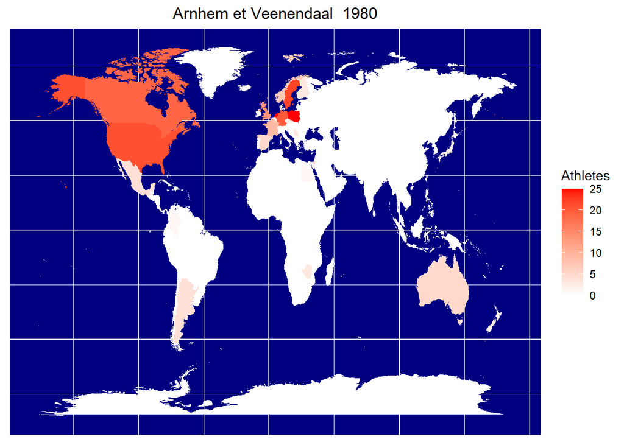

```r
ggplot(world, aes(x = long, y = lat, group = group)) +
  geom_polygon(aes(fill = Arnhem)) +
  labs(title = "Arnhem et Veenendaal  1980",
       x = NULL, y = NULL) +
  theme(axis.ticks = element_blank(),
        axis.text = element_blank(),
        panel.background = element_rect(fill = "navy"),
        plot.title = element_text(hjust = 0.5)) +
  guides(fill=guide_colourbar(title="Athletes")) +
  scale_fill_gradient2(low="white",high = "red")
```

la catographie: Rio 2016

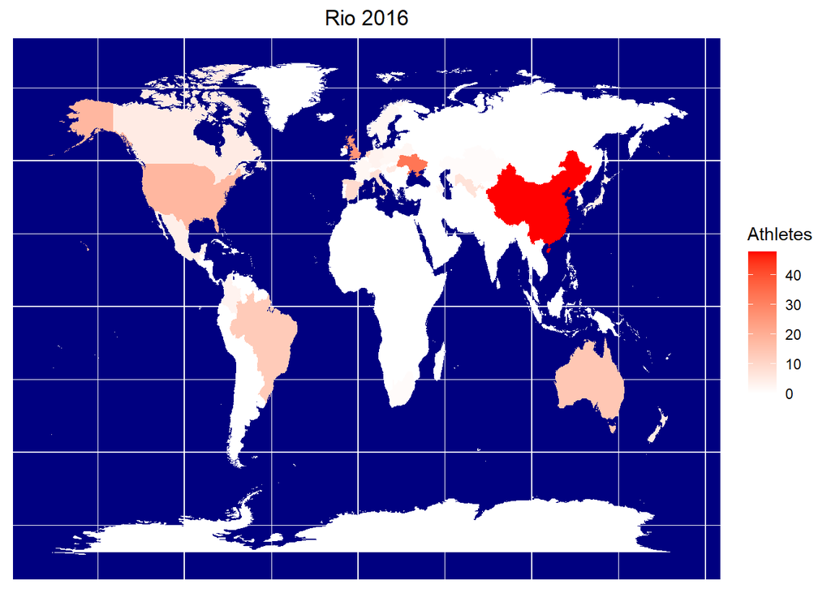

```r
ggplot(world, aes(x = long, y = lat, group = group)) +
  geom_polygon(aes(fill = Rio)) +
  labs(title = "Rio 2016",
       x = NULL, y = NULL) +
  theme(axis.ticks = element_blank(),
        axis.text = element_blank(),
        panel.background = element_rect(fill = "navy"),
        plot.title = element_text(hjust = 0.5)) +
  guides(fill=guide_colourbar(title="Athletes")) +
  scale_fill_gradient2(low="white",high = "red")
```

### La décomposition en continent :

Rajouter une colonne continent:

```r
continent <-readr::read_csv('https://raw.githubusercontent.com/youmrg/data_R/main/data.csv')
continent = continent %>%
  rename(abb = Three_Letter_Country_Code)

medal_continent <- SW %>%
left_join(continent,by="abb") %>%
  filter(!is.na(Continent_Name))
```

#### **10.Combien chaque continent à de médailles ?

Le nombre de medailles en détail de chaque continent par année :

```r
medal_continent<- medal_continent %>%
  group_by(year,Continent_Name) %>%
  summarize(Count=length(medal))
medal_continent
```

```
## # A tibble: 55 x 3
## # Groups:   year [10]
##     year Continent_Name Count
##    <dbl> <chr>          <int>
##  1  1980 Africa             1
##  2  1980 Asia              25
##  3  1980 Europe           238
##  4  1980 North America    119
##  5  1980 Oceania           13
##  6  1980 South America     13
##  7  1984 Africa             1
##  8  1984 Asia              38
##  9  1984 Europe           455
## 10  1984 North America    212
## # ... with 45 more rows
```

Le total des medailles de chaque continent :

```r
sum_medal_cont <- medal_continent %>%
  group_by(Continent_Name) %>%
  summarize(nombre_de_medailles=sum(Count))
 sum_medal_cont
```

```
## # A tibble: 6 x 2
##   Continent_Name nombre_de_medailles
##   <chr>                        <int>
## 1 Africa                          10
## 2 Asia                           765
## 3 Europe                        2759
## 4 North America                 1088
## 5 Oceania                        528
## 6 South America                  178
```

Le pourcentage de chaque continent dans le total des médailles :

```r
pie_chart<- sum_medal_cont %>%
  mutate(perc = `nombre_de_medailles` / sum(`nombre_de_medailles`)) %>%
  arrange(perc) %>%
  mutate(labels = scales::percent(perc))
pie_chart
```

```
## # A tibble: 6 x 4
##   Continent_Name nombre_de_medailles    perc labels
##   <chr>                        <int>   <dbl> <chr>
## 1 Africa                          10 0.00188 0.2%
## 2 South America                  178 0.0334  3.3%
## 3 Oceania                        528 0.0991  9.9%
## 4 Asia                           765 0.144   14.4%
## 5 North America                 1088 0.204   20.4%
## 6 Europe                        2759 0.518   51.8%
```

Le camembert :

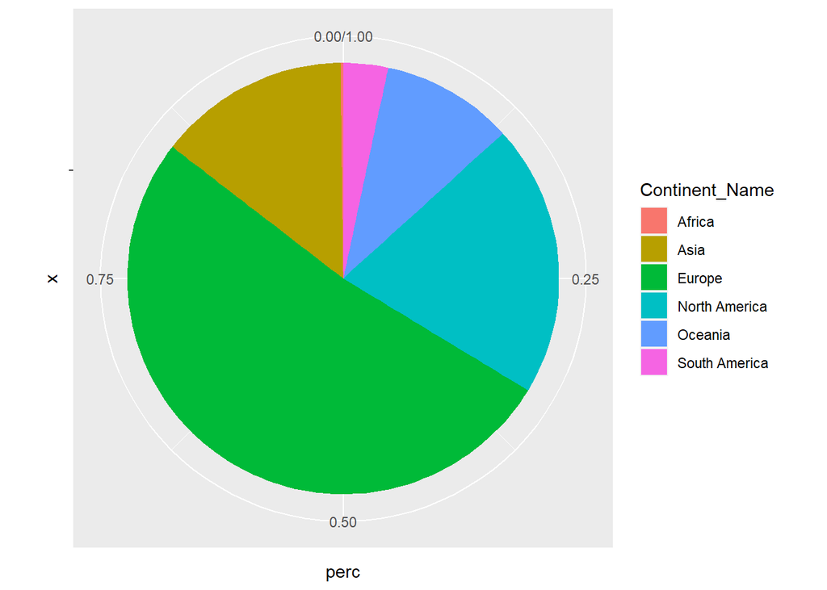

```r
ggplot(pie_chart, aes(x = "", y = perc, fill = Continent_Name)) +
  geom_col() +
  coord_polar(theta = "y")
```

#### **10.quelle l’evolution des nombres de medailles par continent au fil des années ?

Nous voulons ici que le nombre de médailles change en fonction des années et des continent. Nous utiliserons alors un diagramme à barres:

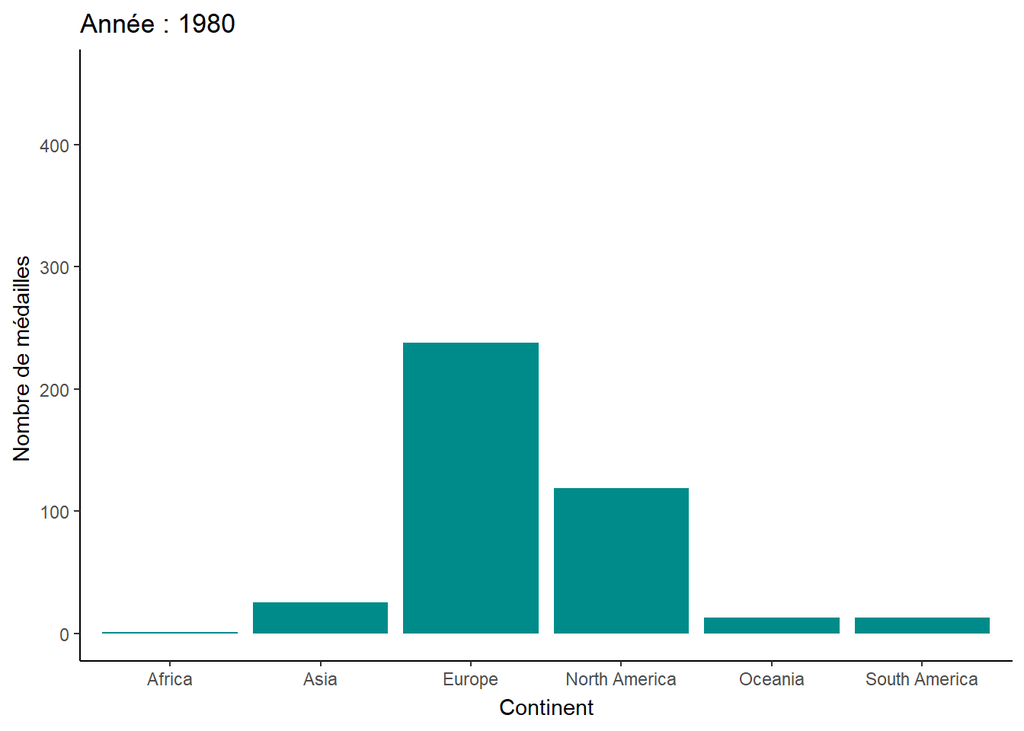

```r
plot_anime1 <- ggplot(data = medal_continent) +
  geom_col(mapping = aes(x = Continent_Name, y = Count),
           fill = "darkcyan") +
  theme_classic() +
  xlab("Continent") +
  ylab("Nombre de médailles ") +
  transition_states(year,
                    transition_length = 2,
                    state_length = 1,
                    wrap = TRUE) +
  ggtitle("Année : {closest_state}")
plot_anime1
```